# **EVR 628 Assignments and more :)**

**Author:** Lina Aragón linamaragonb@gmail.com

This repository has been created as part of the EVR 628 course (Introduction to Data Management and Visualization for Environmental Scientists) from the University of Miami. Here, I will upload my unique solutions for the assignments Dr. Juan Carlos Villaseñor-Derbez (JC) designed.

## **First assignment**

The first assignment was to create this repository. So, Voila :) !!

When creating the project, I used the “EVR628tools” package designed by Dr. Villaseñor-Derbez to make the project structure that will contain everything I will do to achieve each assignment’s goal. I used the function create_dirs(), and with this one, I gave the repository the following structure:

- `data`:
  - `data/raw`:
  - `data/processed`:
- `scripts`:
  - `scripts/01_processing`:
  - `scripts/02_analyses`:
  - `scripts/03_contents`: contains a single file showing the code to create this structure
- `results`:
  - `results/img`:
  - `results/tab`:

## **Second assignment**

The second assignment is a bit more fun and interesting than the first one. For this one, we should find a messy dataset and shape it so that we are ready to analyze data and make figures.

I wanted to do something unrelated to my plant ecologist science hat. I have been working a lot analyzing pretty awesome data, so taking a break from that sounded like a great idea. Inspired by one of Dr. Villaseñor-Derbez’s suggestions, I decided to download the data my Garmin Venu 3S has been collecting since May 9, 2025. You can find what I did in this script.

### **About the data**

- `activity_type` - Character - A unique identifier for each type of activity (i.e., Strenght training, HIIT, Running, among others)
- `date` - Date - A unique identifier for each activity’s date and time
- `star_time` - Period - Time of day the activity started
- `month` - Numerical - The month in which the activity happened in digit format
- `month_abbr` - Character - The month in which the activity happened in letter format ordered
- `day` - Integer - The day in which the activity happened
- `year` - Character - The year in which the activity happened
- `specific_info` - Character - A unique identifier for specific information regarding the activity (i.e., place (Coral_Gables))
- `distance` - Numerical - A distance metric for activities like running, walking and hiking
- `distance` - Numerical - The calories burned during the activity
- `time` - Time - The time I spent doing each activity
- `avg_hr` - Numerical - Average HR during the activity
- `max_hr` - Numerical - Maximum HR during the activity
- `avg_hr` - Numerical - Average HR during the activity
- `avg_speed` - Numerical - Average speed during the activity
- `max_speed` - Numerical - Average speed during the activity
- `total_ascent` - Numerical - Total ascent during the activity
- `total_descent` - Numerical - Total descent during the activity
- `avg_stride_length` - Numerical - Average stride during the activity
- `avg_vertical_ratio` - Numerical - Average vertical ratio during the activity
- `avg_vertical_oscillation` - Numerical - Average vertical oscillation during the activity
- `avg__length` - Numerical - Average stride during the activity
- `avg__ground_contact_time` - Numerical - Average ground contact time during the activity
- `avg__power` - Numerical - Average power during the activity
- `max__power` - Numerical - Max power during the activity
- `steps` - Numerical - Steps taken during the activity
- `total_reps` - Numerical - Total repetitions during the activity
- `total_sets` - Numerical - Total sets during the activity
- `body_battery_drain` - Numerical - How much the activity drained my energy
- `best_lap_time` - Time - Best lap during the activity
- `number_of_laps` - Numerical - Number of laps during the activity
- `moving_time` - Time - Amount of time I move during the activity
- `elapsed_time` - Time - Elapsed time during the activity
- `min_elevation` - Numerical - Min elevation during the activity
- `max_elevation` - Numerical - Max elevation during the activity

## **Third assignment**

For this assignment, Dr. JC asked us to visualize the data from the dataset we cleaned for assignment 2. Before working on this new assignment, I first downloaded my most recent data and then modified some lines of my clean_garmin_dataset.R code to utilize the “lubridate” package for handling dates and times.

I was first interested in the differences between my average and maximum heart rates during High Intensity Interval Training (HIIT), running and strength training activities. Therefore, I transformed my table into a long one to have a column for the type of summary statistic used (mean vs max) and another column for the heart rate value. Afterward, I plotted my average and maximum heart rate for each activity over the months I have had my watch. I used facet_wrap to show the difference between Average and Maximum heart rates. Here is my visualization:

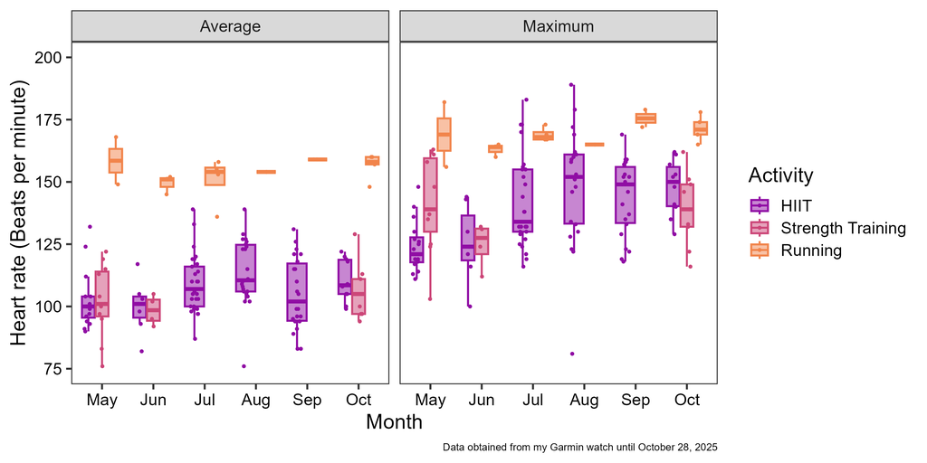

I was also interested in my hiking and running endeavors. So, I decided to visualize the distance (Km) covered while running and hiking for each month of the year, and also study the relationship between the distance (Km) I covered and my total ascent (m), average hear rate (bpm), and maximum heart rate (bpm). I created each plot invidually. I extracted the legends for plot A and plot D using the get_legend function. I created a plot text for the caption. And, finally I used the plot_grid multiple times to be able to create the final visualization. Here is my visualization:

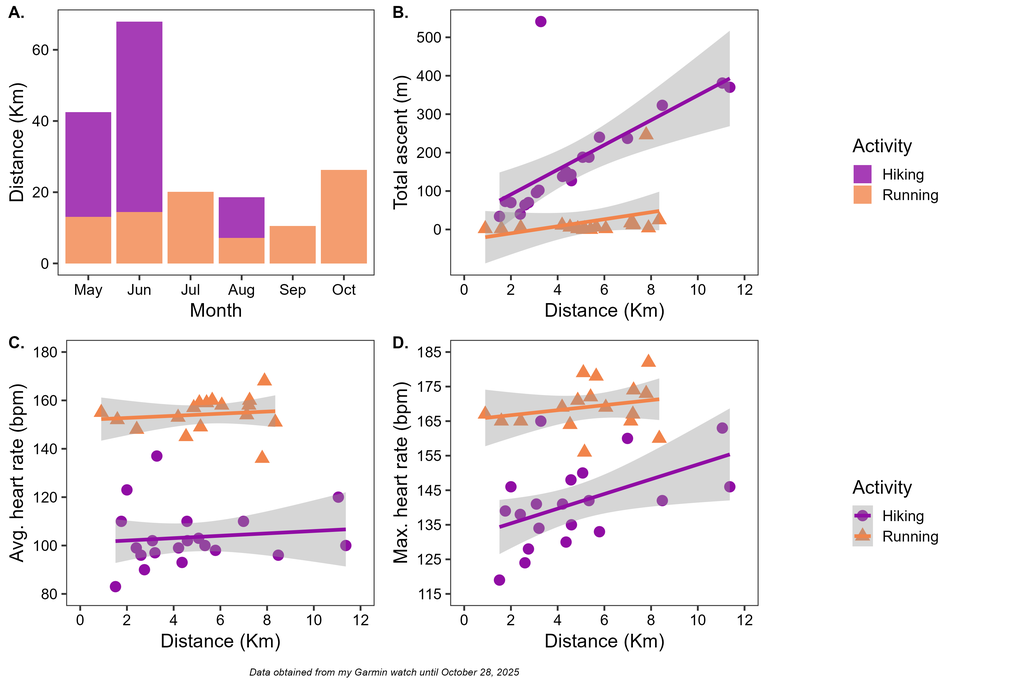

## **Forth assignment**

For this assignment, Dr. JC encouraged us to visualize our data spatially. I didn’t think this was possible for my data given that I didn’t have coordinates from it. However, in the specific information column I have kept since the beginning the location of my Running and Hiking activites was saved.

Using a geocode approach, I first obtain the coordinates for each of my running and hiking activities. Then, I decided to map them per state to try to visualize where in the world I have been doing more running and/or hiking.

Here is the total number of both running and hiking activities I have recorded with my watch around the Americas

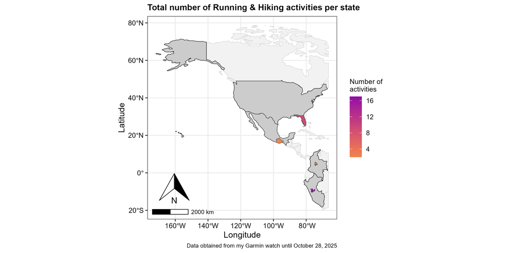

And also, the total number of running

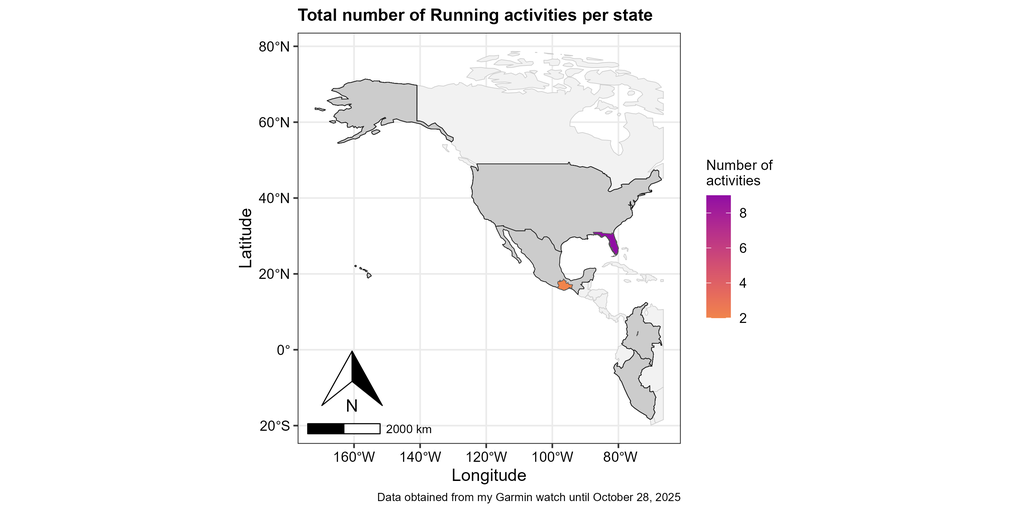

and hiking activities

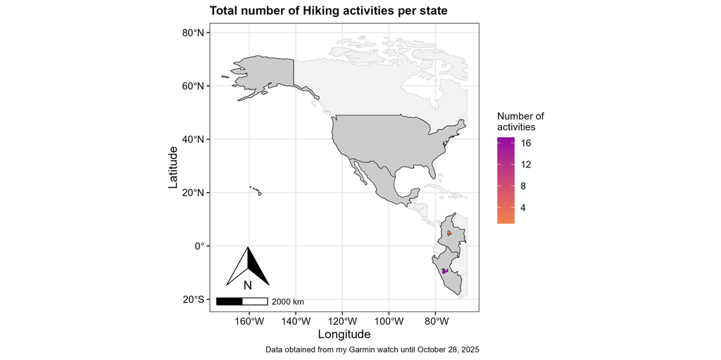

## **Final assignment**

The final step was to create an awesome presentation using Quarto. Here is mine.